# Determination of insurance zones

Benson Kenduiywo

04/06/2020

## Data preparation

Load libraries. To install *agrodata* library use `remotes::install_github("reagro/agrodata")`.

```r
rm(list = ls(all=TRUE))
library(agrodata)
library(reshape2)
library(dplyr)
```

### Administrative data

Load sub-location boundaries

```r
subloc <- agrodata::data_ibli("marsabit")
names(subloc)[6] <- "sublocation"
subloc
```

```
## class       : SpatVector
## geometry    : polygons
## elements    : 58
## extent      : 36.18001, 38.96632, 1.261462, 4.452989  (xmin, xmax, ymin, ymax)
## coord. ref. : +proj=longlat +datum=WGS84 +no_defs
## names       : COUNTRY, PROVINCE, DISTRICT, DIVISION, LOCATION, sublocation, IBLI_UNIT, IBLI_ID
```

### NDVI and rainfall data.

Get Normalized Difference Vegetative Index (NDVI) data from NOAA-AVHRR and rainfall from CHIRPS.

```r
n <- agrodata::data_ibli("marsabit_avhrr_ndvi") #NOAA
colnames(n)[1:5]
```

```
## [1] "SUBLOCATION" "X19810630"   "X19810701"   "X19810702"   "X19810703"
```

```r
p <- agrodata::data_ibli("marsabit_chirps_precipitation")
colnames(p)[1:5]
```

```
## [1] "SUBLOCATION" "X19810101"   "X19810102"   "X19810103"   "X19810104"
```

Reshape the data from wide to long with date as a variable. For more [see](http://www.cookbook-r.com/Manipulating_data/Converting_data_between_wide_and_long_format/).

```r
p <- melt(p, variable.name = "date", value.name = "rainfall",id.vars = "SUBLOCATION")
p[1,]
```

```
##   SUBLOCATION      date rainfall
## 1     MAJENGO X19810101        0
```

```r
n <- melt(n, variable.name = "date", value.name = "ndvi", id.vars = "SUBLOCATION")
n[1,]
```

```
##   SUBLOCATION      date      ndvi
## 1     MAJENGO X19810630 0.2976625
```

Format the date variable by removing unnecessary variables.

```r
#Chirps
date <- gsub("X", "", p$date)
p$date <- as.Date(as.character(date), format = "%Y%m%d")
p[1,]
```

```
##   SUBLOCATION       date rainfall
## 1     MAJENGO 1981-01-01        0
```

```r
#NOAA
date <- gsub("X", "", n$date)
n$date <- as.Date(as.character(date), format = "%Y%m%d")
n[1,]
```

```
##   SUBLOCATION       date      ndvi
## 1     MAJENGO 1981-06-30 0.2976625
```

Compute daily average rainfall and NDVI per season in each year. First Create a function to compute means for Long Rain Long Dry (March – September) and Short Rain Short Dry (October – February) seasons.

```r
seasonMean <- function(year, df, season){
    df$date <- as.Date(df$date, format = "X%Y%m%d")
  if(season =="long"){
    sdate <- paste0(year, "-03-01")
    edate <- paste0(year, "-09-30")
    season <- "LRLD"
  }else if (season =="short"){
    sdate <- paste0(year-1, "-10-01")
    edate <- paste0(year, "-02-28")
    season <- "SRSD"
  }else{
    print("Define season")
  }
  ydf <- df[df$date >= sdate & df$date <= edate, ]
  ym <- aggregate(ydf[,3], ydf[,1, drop=FALSE], mean, na.rm=T)
  ym$year <- year
  ym$season <- season
  return(ym)
}
```

Now compute the averages using the function.

```r
years <- seq(1982, 2019, 1)
LR_rain <- lapply(years, seasonMean, p, "long")
LR_rain <- do.call(rbind, LR_rain)
names(LR_rain)[2] <- "rainfall"
SR_rain <- lapply(years, seasonMean, p, "short")
SR_rain <- do.call(rbind, SR_rain)
names(SR_rain)[2] <- "rainfall"
rain <- rbind(LR_rain, SR_rain)
#NDVI
LR_ndvi <- lapply(years, seasonMean, n, "long")
LR_ndvi <- do.call(rbind, LR_ndvi)
names(LR_ndvi)[2] <- "ndvi"
SR_ndvi <- lapply(years, seasonMean, n, "short")
SR_ndvi <- do.call(rbind, SR_ndvi)
names(SR_ndvi)[2] <- "ndvi"
ndvi <- rbind(LR_ndvi, SR_ndvi)
```

Compute the zScored daily average rainfall per season per sublocation.

```r
zscore <- function(y){
  (y - mean(y, na.rm=TRUE) ) / (sd(y, na.rm=TRUE))
  }

rain <- ungroup(mutate(group_by(rain,SUBLOCATION, season),
                       zrain=zscore(rainfall)))

ndvi <- ungroup(mutate(group_by(ndvi,SUBLOCATION, season),
                       zndvi=zscore(ndvi)))
```

### Livestock data

Mortality and causes of mortality data

```r
mort <- agrodata::data_ibli("marsabit_mortality.rds")
cause <- agrodata::data_ibli("marsabit_losses")[,c("hhid", "sublocation", "cause","month", "year")]
cause$season <- "SRSD"
cause$season[cause$month >=3 & cause$month <=9] <-"LRLD"
head(cause, n=2)
```

```
##     hhid sublocation              cause month year season
## 342 1002 DAKABARICHA Starvation/Drought     7 2009   LRLD
## 343 1002 DAKABARICHA Starvation/Drought     8 2009   LRLD
```

```r
cause <- na.omit(cause)
```

Merge causes table with mortality data.

```r
mort2  <- merge(mort, cause, by=c("hhid","sublocation", "season", "year"))
```

Compute mortality

```r
#Consider: Disease, Starvation, Rain, predation
mort2 <- mort2[!(mort2$cause %in% c("Just lost", "Old age","Premature birth")),]
mort2 <- mort2[mort2$type == "TLU", ]
mort2 <- na.omit(mort2)
amort <- aggregate(mort2[,c("stock_beginning", "loss"), drop=FALSE], mort2[, c("season","year","sublocation"), drop=FALSE], mean, na.rm=TRUE)
amort$mortality_rate <- amort$loss/amort$stock_beginning
```

### Merge mortality with NDVI and rainfall data.

```r
colnames(ndvi)[1] <- "sublocation"
d <- merge(ndvi, amort, by=c("year", "season", "sublocation"))
colnames(rain)[1] <- "sublocation"
d <- merge(rain, d, by=c("year", "season", "sublocation"))
d$mortality_rate <- d$mortality_rate * 100
```

## Spatial Variation of mortality

Display the spatial variation on mortality.

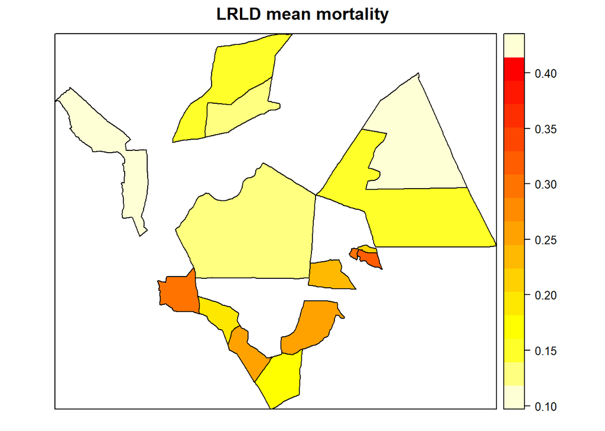

```r
temp <- aggregate(amort[, "mortality_rate", drop=FALSE], amort[, c("season", "sublocation"), drop=FALSE],mean, na.rm=T)
#LRLD
lr <- terra::merge(subloc, temp[temp$season=="LRLD", c("sublocation", "mortality_rate")], by= "sublocation")
#SRSD
sr <- terra::merge(subloc, temp[temp$season=="SRSD", c("sublocation", "mortality_rate")], by= "sublocation")

cols <- heat.colors(length(lr$sublocation), rev=T)
#Rainfal spatial variation
#x11()
par(mfrow=c(1, 2), mar=c(1, 1, 2, 2)) #c(bottom, left, top, right)
raster::spplot(lr, "mortality_rate", col.regions=cols, main="LRLD mean mortality")
```

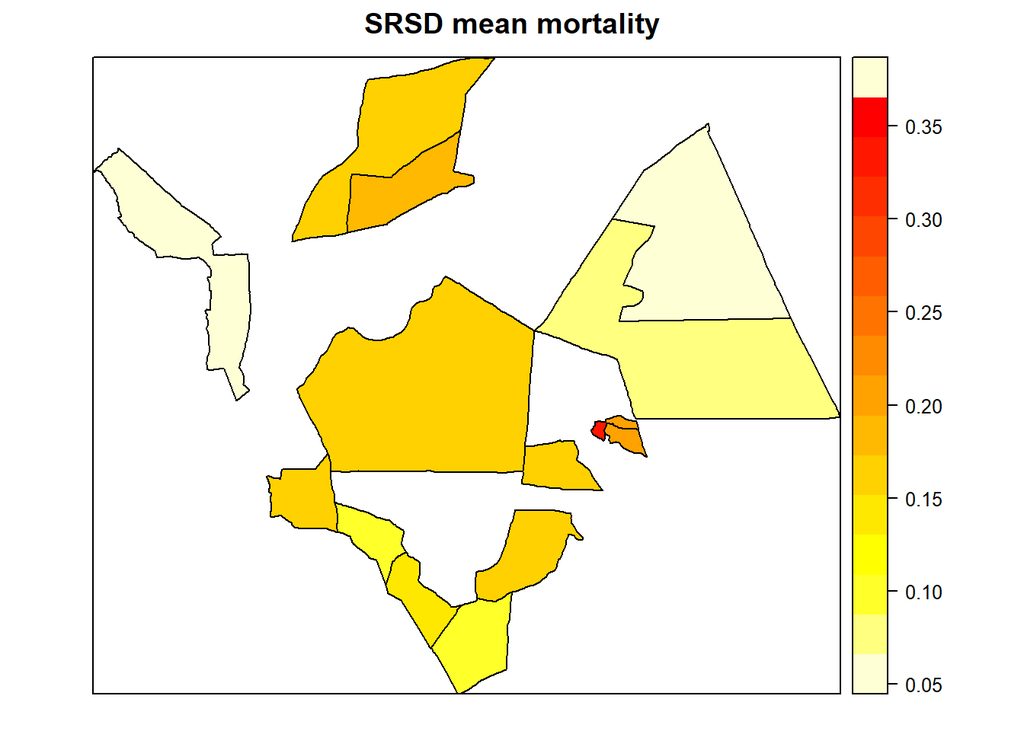

```r
raster::spplot(sr, "mortality_rate", col.regions=cols, main="SRSD mean mortality")
```

## Clustering zones

Use kmeans to cluster zones based on NDVI and rainfall per season per year

```r
n_w <- reshape2::dcast(ndvi, sublocation ~ year+season, value.var="zndvi")
r_w <- reshape2::dcast(rain, sublocation ~ year+season, value.var="zrain")
df <- merge(n_w,r_w, by=c("sublocation"))
subs <- sort(unique(d$sublocation))
aoi <- subloc[subloc$sublocation %in% subs,]
df1 <- df[df$sublocation %in% subs,]
set.seed(99)
#rf <-  randomForest(df[,-1],ntree=200,importance = TRUE)
#Create 10 clusters using 500 iterations using 5 random sets from "Lloyd" method
r_kmn <- kmeans(df1[,-1], centers = 10, iter.max = 500, nstart = 5, algorithm="Lloyd")
# kmeans returns an object of class "kmeans"
aoi$Zones <- r_kmn$cluster
```

Display the old and new zones

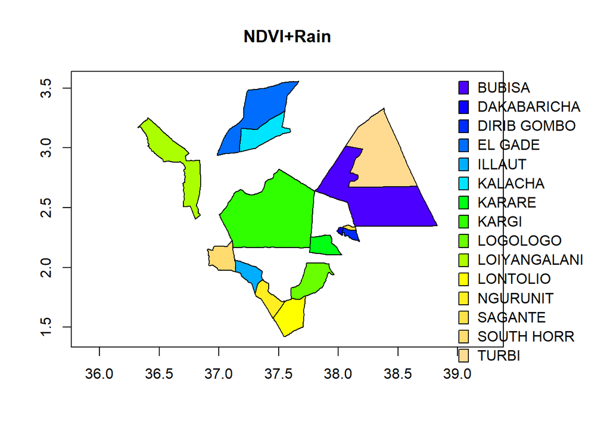

```r
x11()
#par(mfrow=c(2, 1), mar=c(4, 4, 1, 10)) #c(bottom, left, top, right)
plot(aoi, "sublocation", main= "NDVI+Rain")
```

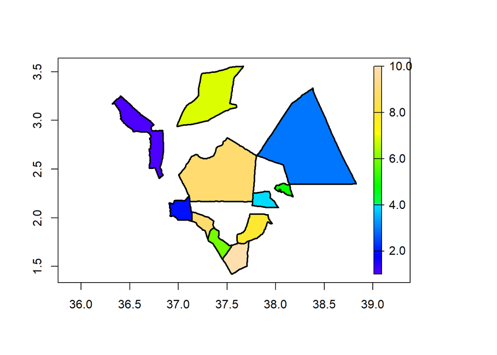

```r
#Merge to current boundaries
x11()
z_10 <- aggregate(aoi, by="Zones")
plot(z_10, "Zones", add=T, lwd = 2)
```

```r
#legend("bottomleft", c("Original", "Clustered"), col=c("black","red"), lty = 1, lwd=2, title="Sublocation clusters")
```

## Effect of zones on mortality predictions

MAPE, RMSE and R$^2$ functions are given as:

```r
rmse <- function(error){ return(sqrt(mean(error^2)))}
MAPE <- function (y_pred, y_true){ mean(abs((y_true - y_pred)/y_true)) * 100 }
R_square <- function(actual, predicted) { 1 - (sum((actual-predicted)^2)/sum((actual-mean(actual))^2))}
```

Let now determine homogenous zones between 2–15 i.e. minimum zones are 2 and maximum is 15 (basically adopt all sub-locations are zones).

```r
zones <- seq(2,15,1)
r_n <- e_n <- r_r <- e_r <- mape_n <- mape_r <- NULL
#Construct a Global mortality model based on NDVI & rainfall
#m_r <- loess(mortality_rate ~ zrain , data=d, control=loess.control(surface="direct"))
#m_n <- loess(mortality_rate ~ zndvi, data=d, control=loess.control(surface="direct"))

for(z in 1:length(zones)){
  set.seed(99)
  r_kmn <- kmeans(df1[,-1], centers = zones[z], iter.max = 500, nstart = 2, algorithm="Lloyd")
  aoi$Zones <- r_kmn$cluster
  df2 <- merge(d, as.data.frame(aoi[,c("sublocation", "Zones")]), by="sublocation")
  df2 <- ungroup(mutate(group_by(df2, season, Zones),
                       zrain=zscore(rainfall), zndvi=zscore(ndvi)))
  df2 <- ungroup(mutate(group_by(df2, year, season, Zones),
                       mortality_rate=mean(mortality_rate)))
  #Rainfall
  m_r <- loess(mortality_rate ~ zrain , data=df2, control=loess.control(surface="direct"))
  p <- predict(m_r, df2)
  r_r[z] <- R_square(df2$mortality_rate, p)
  e_r[z] <- rmse(df2$mortality_rate - p)
  mape_r[z] <- MAPE(df2$mortality_rate, p)
  #NDVI
  m_n <- loess(mortality_rate ~ zndvi, data=df2, control=loess.control(surface="direct"))
  p <- predict(m_n, df2)
  r_n[z] <- R_square(df2$mortality_rate, p)
  e_n[z] <- rmse(df2$mortality_rate - p)
  mape_n[z] <- MAPE(df2$mortality_rate, p)
}
quality <- data.frame(No_Sub=zones,ndvi_R2=r_n,rain_R2=r_r, ndvi_RMSE=e_n,rain_RMSE=e_r,ndvi_mape=mape_n,rain_mape=mape_r)
quality #No_Sub is the number of sublocation clusters created by K-means
```

```
##    No_Sub   ndvi_R2   rain_R2 ndvi_RMSE rain_RMSE ndvi_mape rain_mape
## 1       2 0.1756667 0.3776753  8.470604  7.359892  30.67146  27.05007
## 2       3 0.1817519 0.3540915  9.335780  8.294565  33.08591  27.39613
## 3       4 0.1758079 0.3177495 10.473324  9.528888  37.84206  33.36474
## 4       5 0.1770178 0.3094413 10.581327  9.692710  38.98378  34.17680
## 5       6 0.2019684 0.2954756 11.541565 10.844329  42.15923  37.92079
## 6       7 0.1763251 0.2680899 11.306185 10.657787  41.63165  37.55602
## 7       8 0.2037173 0.2637961 12.153430 11.685957  45.83206  41.20371
## 8       9 0.1694409 0.2506378 12.765469 12.125437  47.93188  44.88311
## 9      10 0.1815196 0.2697322 12.660060 11.958389  49.01179  44.74944
## 10     11 0.1696879 0.2514259 13.020335 12.362858  50.40807  46.33099
## 11     12 0.1911376 0.2446780 13.061318 12.621638  50.17157  47.18353
## 12     13 0.1986960 0.2453613 13.091782 12.704854  50.00990  48.13778
## 13     14 0.1848445 0.2381829 13.576636 13.124940  52.07916  50.28628
## 14     15 0.1845823 0.2395899 13.611265 13.144146  51.77692  50.55533
```

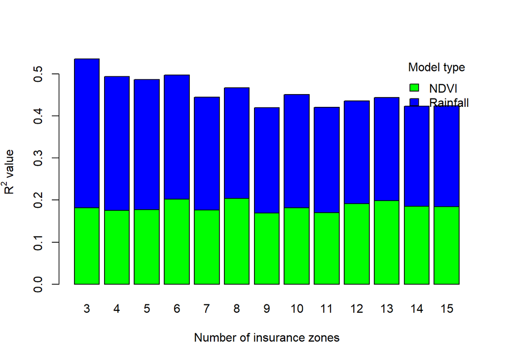

```r
temp <- t(quality)
colnames(temp ) <- quality$No_Sub
temp <- temp[-1,-1]
barplot(temp[1:2,], col=c("green", "blue"), ylab=expression(paste(R^2, " value")), xlab="Number of insurance zones")
legend("topright",   legend=c("NDVI",  "Rainfall"), fill=c("green", "blue"), title=expression(paste("Model type")), bty = "n")
```

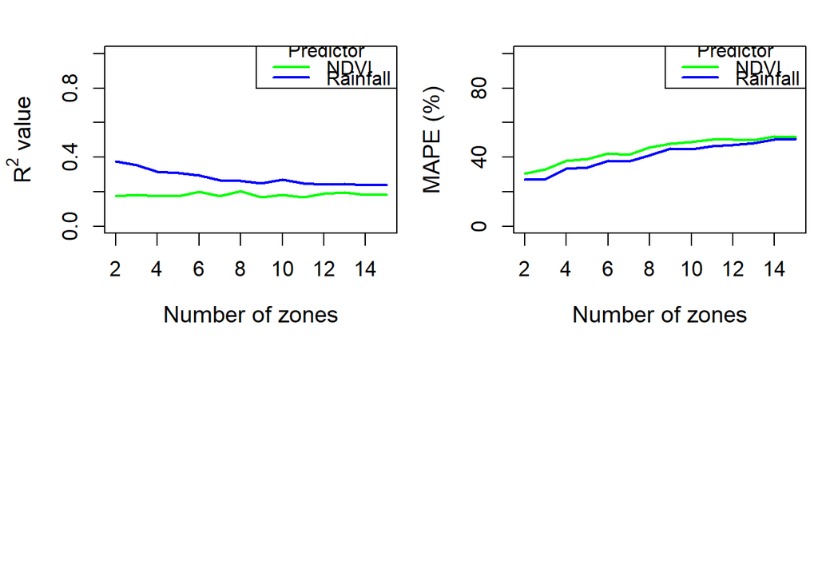

```r
x11()
#par(mfrow=c(1,2),mar=c(15,4.5,1,1))
par(mfrow=c(1, 2), mar=c(15, 4.5, 2, 0.5)) #c(bottom, left, top, right)
plot(zones, r_n, type="l", ylim= c(0,1), col="green", ylab=expression(paste(R^2, " value")), xlab= "Number of zones", cex.axis =1.1, cex.lab = 1.2, lwd=2)
lines(zones, r_r, col="blue", lwd=2)
legend("topright", c("NDVI", "Rainfall"), col=c("green","blue"), lty = 1, lwd=2, title = "Predictor")

plot(zones, mape_n, type="l", ylim= c(0,100), col="green", ylab="MAPE (%)", xlab= "Number of zones", cex.axis =1.1, cex.lab = 1.2,lwd=2)
lines(zones, mape_r, col="blue",lwd=2)
legend("topright", c("NDVI", "Rainfall"), col=c("green","blue"), lty = 1, lwd=2, title = "Predictor")
```

## Influence of number zones on MQS

We evaluate the influence of zone clusters on insurance welfare using MQS based on a risk aversion coefficient $\rho=1.5$ – which falls within the common range for risk-averse farming communities.

```r
library(agro)
test <- function(rhos, df1){
  ce_base <- ce_ins <- ce_ins_nomarkup<- mqs <- mqs_no <- rep(NA, length(rhos))
  for(i in 1:length(rhos)){
    ce_base[i] <- ce_income(df1$y_noins, rhos[i])
    ce_ins[i]  <- ce_income(df1$y_25markup, rhos[i])
    ce_ins_nomarkup[i] <- ce_income(df1$y_nomarkup, rhos[i])
    mqs[i]    <- ce_ins[i] - ce_base[i]
    mqs_no[i] <- ce_ins_nomarkup[i] - ce_base[i]
  }
  return(list(mqs=mqs,mqs_no=mqs_no))
}

markup <- 0.25
rhos <- 1.5 #seq(0, 5, .1)
mqs_n <- mqs_r <- vector("list", length(rhos))
for(z in 1:length(zones)){
  set.seed(99)
  r_kmn <- kmeans(df1[,-1], centers = zones[z], iter.max = 500, nstart = 2, algorithm="Lloyd")
  aoi$Zones <- r_kmn$cluster
  df2 <- 0
  df2 <- merge(d, as.data.frame(aoi[,c("sublocation", "Zones")]), by="sublocation")
  df2 <- ungroup(mutate(group_by(df2, season,Zones),
                       zrain=zscore(rainfall), zndvi=zscore(ndvi)))
  df2 <- ungroup(mutate(group_by(df2, year, season, Zones),
                       mortality_rate=mean(mortality_rate)))
  #1.0 Mortality model
  #Rainfall
  m_r <- loess(mortality_rate ~ zrain , data=df2, control=loess.control(surface="direct"))
  df2$rain_mortality <- predict(m_r, df2)
  #NDVI
  m_n <- loess(mortality_rate ~ zndvi, data=df2, control=loess.control(surface="direct"))
  df2$ndvi_mortality <- predict(m_n, df2)
  #2.0 Contract design
  r_trig <- quantile(df2$rain_mortality, 0.80, na.rm=T)
  n_trig <- quantile(df2$ndvi_mortality, 0.80, na.rm=T)
  #make payouts; 1 TLU=100$
  df2$r_pay <- pmax(0, df2$rain_mortality - r_trig)/100 * 1000
  df2$n_pay <- pmax(0, df2$ndvi_mortality - n_trig)/100 * 1000
  #3.0 Evaluation
  #NDVI
  df2$capital <- (100 - df2$mortality_rate) * 1000
  n_premium <- mean(df2$n_pay) * (1 + markup)
  df_n <- data.frame(y_noins = df2$capital) # no insurance
  df_n$y_nomarkup <- (df2$capital + df2$n_pay) - mean(df2$n_pay) #no markup
  df_n$y_25markup <- (df2$capital + df2$n_pay) - n_premium #marked up
  #Rainfall model premiums
  r_premium <- mean(df2$r_pay) * (1 + markup)
  df_r <- data.frame(y_noins = df2$capital)
  df_r$y_nomarkup <- (df2$capital + df2$r_pay) - mean(df2$r_pay)
  df_r$y_25markup <- (df2$capital + df2$r_pay) - r_premium
  #4.0 MQS test
  mqs_n[[z]] <- test(rhos, df_n)
  mqs_r[[z]] <- test(rhos, df_r)

}
```

We have made a welfare test on the various zones we have created. Let us now make a plot to evaluate if the size of the zone clusters influence insurance welfare in any way.

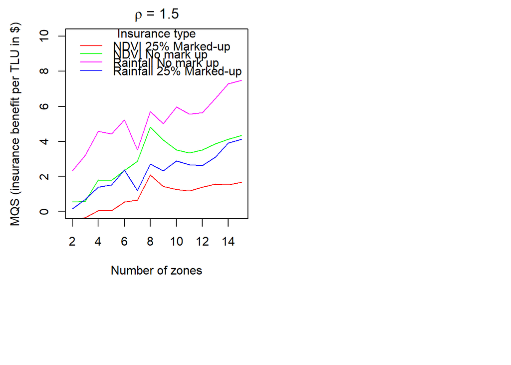

```r
a <-  matrix(unlist(mqs_n),ncol=2,byrow=TRUE)
b <-  matrix(unlist(mqs_r),ncol=2,byrow=TRUE)
x11()
par(mfrow=c(1, 2), mar=c(10, 4.5, 2, 0.5))
plot(zones, a[,1], type="l", col="red", ylab= "MQS (insurance benefit per TLU in $)", xlab="Number of zones", cex=2, ylim=c(0, 10), main=expression(paste(rho," = 1.5")))
lines(zones, a[,2], col="green")
lines(zones, b[,2], col="magenta")
lines(zones, b[,1], col="blue")
legend("top", c("NDVI 25% Marked-up", "NDVI No mark up", "Rainfall No mark up", "Rainfall 25% Marked-up"), lty=1, col=c("red", "green", "magenta", "blue"), title = "Insurance type", bty = "n")
```

Consider a highly risk averse farmer $\rho=5$

```r
rhos <- 5 #seq(0, 5, .1)
mqs_n <- mqs_r <- vector("list", length(rhos))
for(z in 1:length(zones)){
  set.seed(99)
  r_kmn <- kmeans(df1[,-1], centers = zones[z], iter.max = 500, nstart = 2, algorithm="Lloyd")
  aoi$Zones <- r_kmn$cluster
  df2 <- 0
  df2 <- merge(d, as.data.frame(aoi[,c("sublocation", "Zones")]), by="sublocation")
  df2 <- ungroup(mutate(group_by(df2, season,Zones),
                       zrain=zscore(rainfall), zndvi=zscore(ndvi)))
  df2 <- ungroup(mutate(group_by(df2, year, season, Zones),
                       mortality_rate=mean(mortality_rate)))
  #1.0 Mortality model
  #Rainfall
  m_r <- loess(mortality_rate ~ zrain , data=df2, control=loess.control(surface="direct"))
  df2$rain_mortality <- predict(m_r, df2)
  #NDVI
  m_n <- loess(mortality_rate ~ zndvi, data=df2, control=loess.control(surface="direct"))
  df2$ndvi_mortality <- predict(m_n, df2)
  #2.0 Contract design
  r_trig <- quantile(df2$rain_mortality, 0.80, na.rm=T)
  n_trig <- quantile(df2$ndvi_mortality, 0.80, na.rm=T)
  #make payouts; 1 TLU=100$
  df2$r_pay <- pmax(0, df2$rain_mortality - r_trig)/100 * 1000
  df2$n_pay <- pmax(0, df2$ndvi_mortality - n_trig)/100 * 1000
  #3.0 Evaluation
  #NDVI
  df2$capital <- ((100 - df2$mortality_rate)/100) * 1000
  n_premium <- mean(df2$n_pay) * (1 + markup)
  df_n <- data.frame(y_noins = df2$capital) # no insurance
  df_n$y_nomarkup <- (df2$capital + df2$n_pay) - mean(df2$n_pay) #no markup
  df_n$y_25markup <- (df2$capital + df2$n_pay) - n_premium #marked up
  #Rainfall model premiums
  r_premium <- mean(df2$r_pay) * (1 + markup)
  df_r <- data.frame(y_noins = df2$capital)
  df_r$y_nomarkup <- (df2$capital + df2$r_pay) - mean(df2$r_pay)
  df_r$y_25markup <- (df2$capital + df2$r_pay) - r_premium
  #4.0 MQS test
  mqs_n[[z]] <- test(rhos, df_n)
  mqs_r[[z]] <- test(rhos, df_r)

}
```

Make a plot to evaluate if the size of the zone clusters influence insurance welfare in any way.

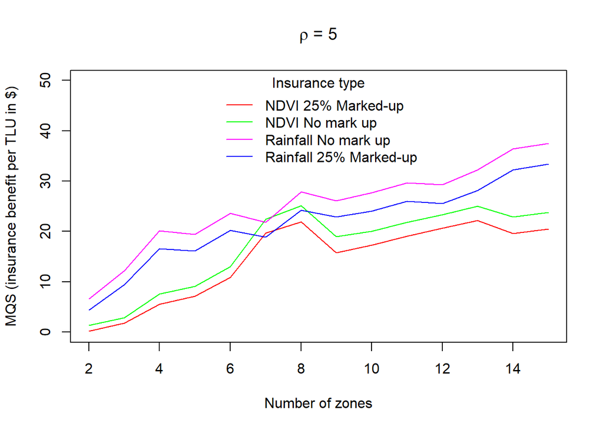

```r
a <-  matrix(unlist(mqs_n),ncol=2,byrow=TRUE)
b <-  matrix(unlist(mqs_r),ncol=2,byrow=TRUE)
plot(zones, a[,1], type="l", col="red", ylab= "MQS (insurance benefit per TLU in $)", xlab="Number of zones", cex=2, ylim=c(0, 50), main=expression(paste(rho," = 5")))
lines(zones, a[,2], col="green")
lines(zones, b[,2], col="magenta")
lines(zones, b[,1], col="blue")
legend("top", c("NDVI 25% Marked-up", "NDVI No mark up", "Rainfall No mark up", "Rainfall 25% Marked-up"), lty=1, col=c("red", "green", "magenta", "blue"), title = "Insurance type", bty = "n")
```

## References

Lewis, C. D., 1982. *Industrial and business forecasting methods: a practical guide to exponential smoothing and curve fitting*. Butterworth Scientific, London Boston.